# Functions to Automate Preliminary Bivariate Analyses

Mike Kirkpatrick

December 22, 2017

## Overview

This code is designed to expedite the preliminary bivariate comparisons that are usually done prior to statistical modeling.

For example, if you are going to run a multiple regression model, you likely will test each independent variable against your dependent variable to see if there is a statisticaly significant relationship. Additionally, you will probably create a plot visualizing the statistically significant relationships.

These exploratory analyses, although important, can become painfully monotonous. Therefore, I wrote this code to automate this process for **continuous** and **dichotomous** dependent variables. This file illustrates how the code could be used on the `mtcars` data set.

## Data Preparation

First I simply import and then view the [mtcars](https://stat.ethz.ch/R-manual/R-devel/library/datasets/html/mtcars.html) dataset.

```r
data(mtcars)
head(mtcars)
```

```
##                    mpg cyl disp  hp drat    wt  qsec vs am gear carb
## Mazda RX4         21.0   6  160 110 3.90 2.620 16.46  0  1    4    4
## Mazda RX4 Wag     21.0   6  160 110 3.90 2.875 17.02  0  1    4    4
## Datsun 710        22.8   4  108  93 3.85 2.320 18.61  1  1    4    1
## Hornet 4 Drive    21.4   6  258 110 3.08 3.215 19.44  1  0    3    1
## Hornet Sportabout 18.7   8  360 175 3.15 3.440 17.02  0  0    3    2
## Valiant           18.1   6  225 105 2.76 3.460 20.22  1  0    3    1
```

Then I create an analysis data set (`df`). I change `cyc` to a categorical factor variable. I recode the variables `am` and `vs` and make them categorical factor variables.

```r
df <- mtcars

df$cyl <- as.factor(df$cyl)

df$am <- as.factor(
  sapply(df$am, function(i)
  if (i == 0) {"automatic"}
  else if (i==1) {"manual"}
))

df$vs <- as.factor(
  sapply(df$vs, function(i)
    if (i == 0) {"V-engine"}
    else if (i==1) {"Straigt engine"}
  ))

head(df)
```

```
##                    mpg cyl disp  hp drat    wt  qsec             vs
## Mazda RX4         21.0   6  160 110 3.90 2.620 16.46       V-engine
## Mazda RX4 Wag     21.0   6  160 110 3.90 2.875 17.02       V-engine
## Datsun 710        22.8   4  108  93 3.85 2.320 18.61 Straigt engine
## Hornet 4 Drive    21.4   6  258 110 3.08 3.215 19.44 Straigt engine
## Hornet Sportabout 18.7   8  360 175 3.15 3.440 17.02       V-engine
## Valiant           18.1   6  225 105 2.76 3.460 20.22 Straigt engine
##                          am gear carb
## Mazda RX4            manual    4    4
## Mazda RX4 Wag        manual    4    4
## Datsun 710           manual    4    1
## Hornet 4 Drive    automatic    3    1
## Hornet Sportabout automatic    3    2
## Valiant           automatic    3    1
```

## Set Default Parameters

I used only base R packages except for the `car` package, which is needed to get the ANOVA p-values for dichotomous DVs. I chose to set my `alpha` level to 0.05 for determining statistical significance. The value I choose for `alpha` here doesn’t affect the actual statistical tests. Rather, it simply changes the label the IV is given in the summary table (more on that later). The `yrange` function makes the y-axis of charts 25% bigger and `color` simply defines two colors to be used in boxplots and barplots.

```r
library(car)
alpha <- 0.05
yrange <- function(y) c(0,max(y)*1.25)
color <- c("coral","aquamarine3")
```

# Continuous Dependent Variable

The following sections are to be used if your dependent variable is **continuous**.

### Table of Statistical Tests

I choose `mpg` as my dependent variable (`DV`). I then create a list of all other variables in my data set and considers them as the independent variables (`IVs`).

```r
DV <- "mpg"
IVs <- colnames(df)[colnames(df)!= DV]
```

I then define a function that will do the following to each DV and IV pair:

1. Create a **linear** regression model such that DV ~ IV
2. Create an ANOVA table
3. Create a summary table
4. Extract the degrees of freedom, F-statistic, p-value, r-squared, and put all of these elements into a data frame (table) called “r”
5. Add the name of the DV and IV to the table
6. Determine if the IV is statistically significant based on the `alpha` level I chose previsouly. Add this label to the table
7. Reset the `rownames`

```r
f.ConDV <- function(IV) {
  m <- lm (df[,DV] ~ df[,IV])
  a <- anova(m)
  s <- summary(m)
  r <- data.frame(cbind(df1=s$fstatistic[2], df2=s$fstatistic[3], F.stat=round(s$fstatistic[1],2), p.value=round(a$`Pr(>F)`[1],3), r.sqr = round(s$r.squared,2)))
  r <- cbind(DV,IV,r)
  r$Sig <- ifelse(r$p.value < alpha,'Yes','No')
  rownames(r) <- NULL
  return(r)
}
```

Now, I apply my function to my data (line 1). I order my table of statistical tests by the p-value and F-statistic. I reset the rownames to preserve this order and then I display the results.

NOTE: This table contains the results of 10 *separate* linear regression models. This table does NOT contain an ANOVA table for a linear regression model that includes all 10 of these IVs.

The results indicate that all of the IVs are statistically significant predictors of `MPG`. The IV `wt` has the strongest relationship with `mpg`, and `qsec` has the weakest.

```r
tbl.ConDV <- do.call(rbind,lapply(IVs, f.ConDV))
tbl.ConDV <- tbl.ConDV[order(tbl.ConDV$p.value,-tbl.ConDV$F.stat),]
rownames(tbl.ConDV) <- NULL
print(tbl.ConDV)
```

```
##     DV   IV df1 df2 F.stat p.value r.sqr Sig
## 1  mpg   wt   1  30  91.38   0.000  0.75 Yes
## 2  mpg disp   1  30  76.51   0.000  0.72 Yes
## 3  mpg   hp   1  30  45.46   0.000  0.60 Yes
## 4  mpg  cyl   2  29  39.70   0.000  0.73 Yes
## 5  mpg drat   1  30  25.97   0.000  0.46 Yes
## 6  mpg   vs   1  30  23.66   0.000  0.44 Yes
## 7  mpg   am   1  30  16.86   0.000  0.36 Yes
## 8  mpg carb   1  30  13.07   0.001  0.30 Yes
## 9  mpg gear   1  30   9.00   0.005  0.23 Yes
## 10 mpg qsec   1  30   6.38   0.017  0.18 Yes
```

### Plots of Statistically Significant IVs

Now that I know which IVs are significant predictors of my DV, I want to visualize each bivariate relationship. To do this, I make sure my DV is still defined. Then I get a list of my statistically significant IVs.

```r
DV <- "mpg"
IVs <- as.matrix(subset(tbl.ConDV,Sig=="Yes",select = IV))
```

I then define a function that will do the following to each DV and IV pair:

1. Determine if the IV is continuous (“numeric”) or categorical (“factor”)
2. If the IV is continuous, create a scatterplot
3. If the IV is categorical, create a boxplot

```r
f.ConDvPlots <- function(IV) {
  if(class(df[,IV])=="numeric") {
    plot(df[,IV],df[,DV], main=paste("Scatterplot of",DV,"by",IV), xlab=IV, ylab=DV, pch=20)
    abline(lm(df[,DV]~df[,IV]), col="red")
    lines(lowess(df[,IV],df[,DV]), col="blue")
  }
  else if (class(df[,IV])=="factor") {
    boxplot(df[,DV] ~ df[,IV], col = color, main=paste("Boxplot of",DV,"by",IV), ylab=DV, xlab=IV)
    }
}
```

I execute the function by simply running the following.

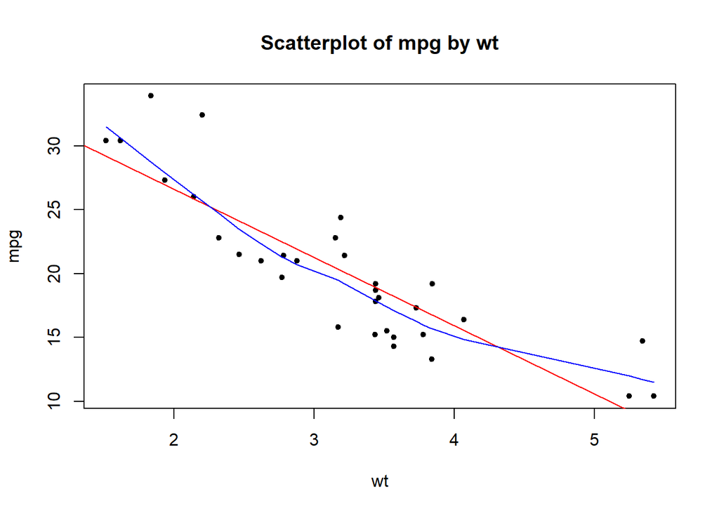

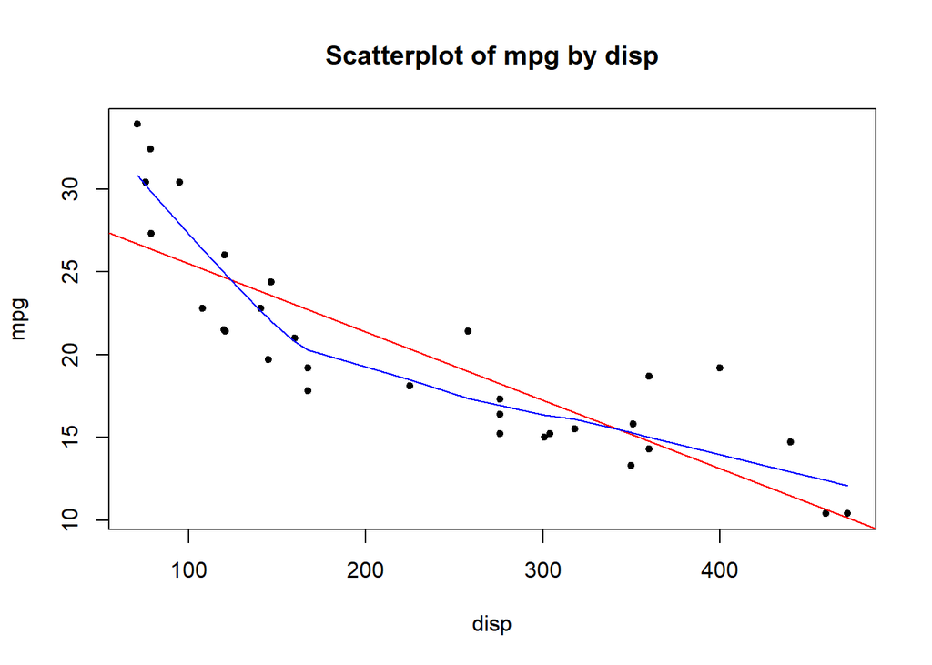

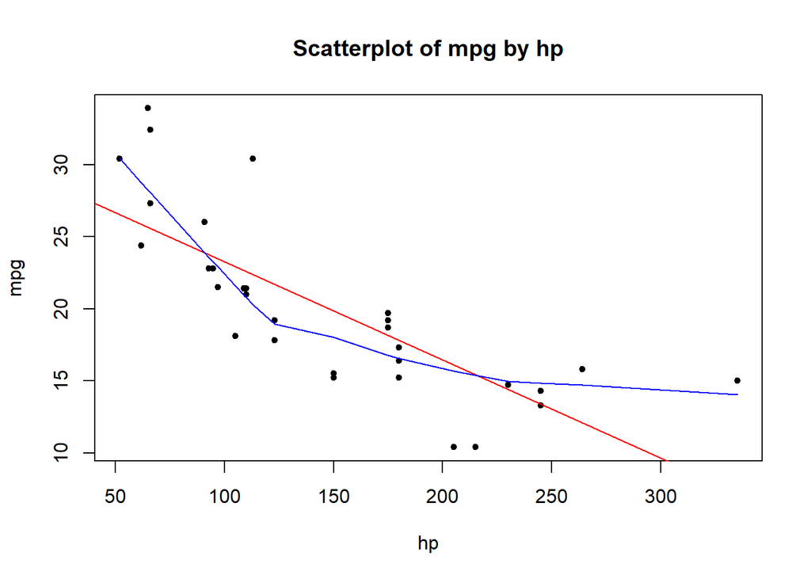

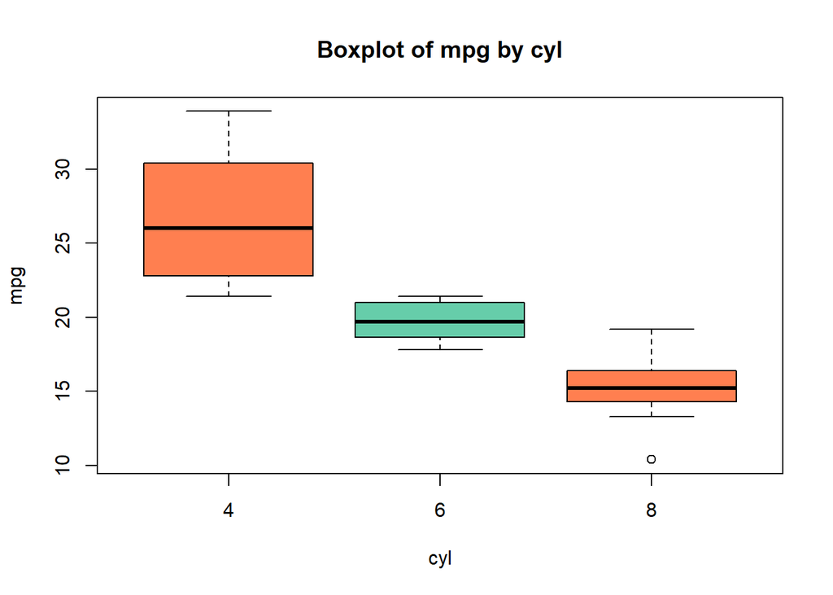

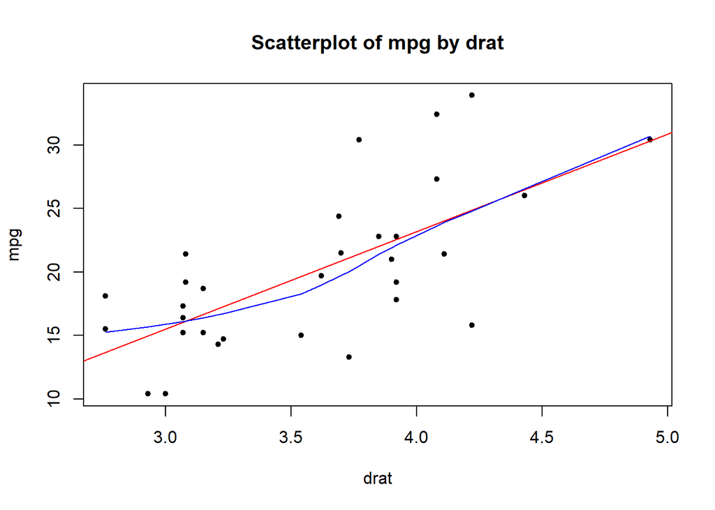

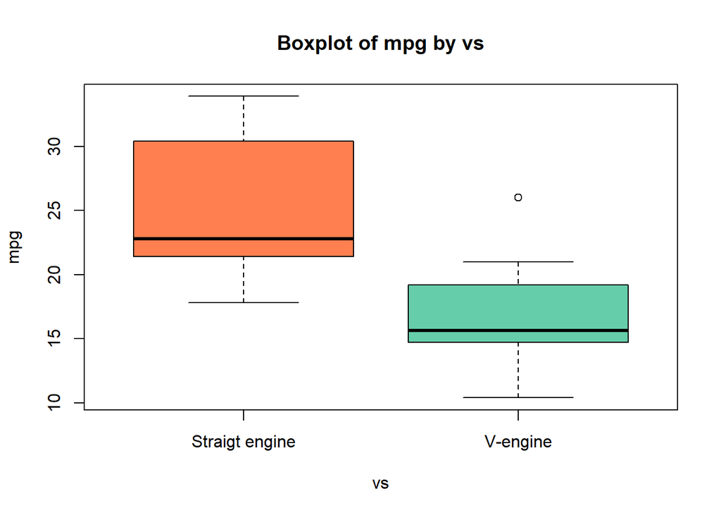

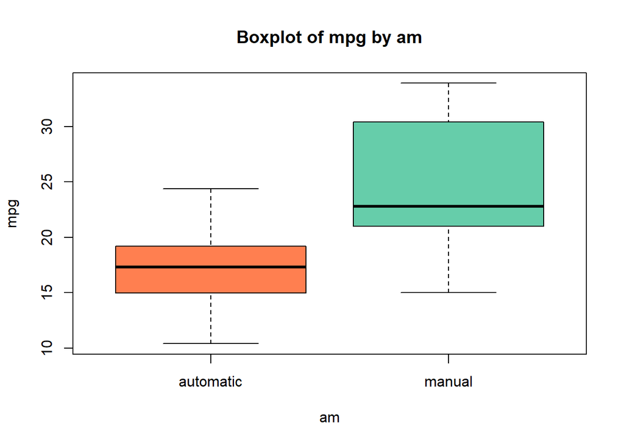

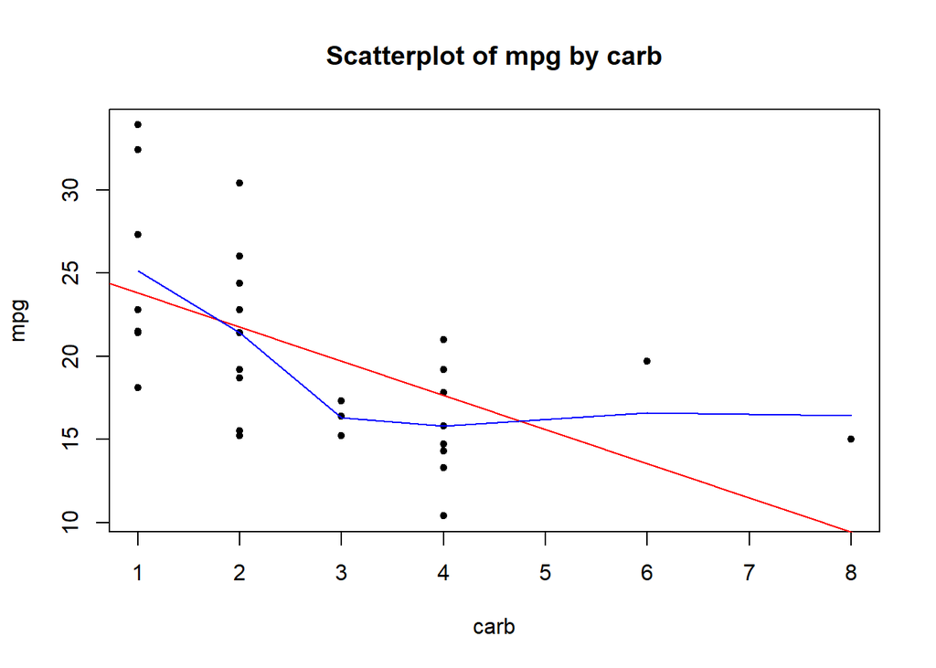

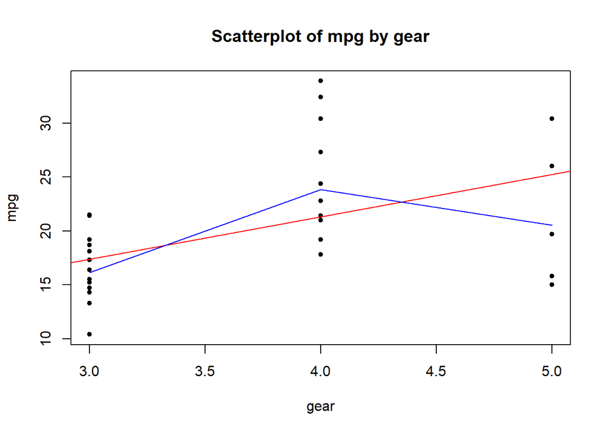

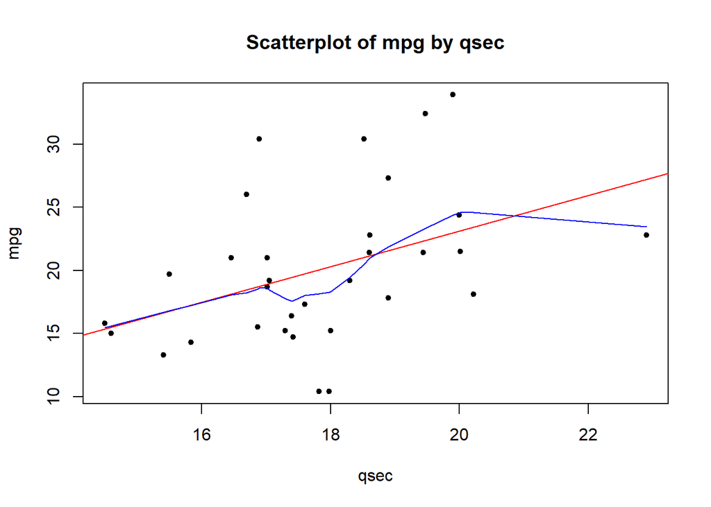

```r
lapply(IVs, f.ConDvPlots)
```

# Dichotomous Categorical Dependent Variable

The following sections are to be used if your dependent variable is **dichotomous**.

### Table of Statistical Tests

I choose `vs` as my dependent variable (`DV`). I then create a list of all other variables in my data set and considers them as the independent variables (`IVs`).

```r
DV <- "vs"
IVs <- colnames(df)[colnames(df)!= DV]
```

I then define a function that will do the following to each DV and IV pair:

1. Create a **logistic** regression model such that DV ~ IV
2. Create an ANOVA table
3. Extract the degrees of freedom, ChiSquare statistic, p-value, and put all of these elements into a data frame (table) called “r”
4. Add the name of the DV and IV to the table
5. Determine if the IV is statistically significant based on the `alpha` level I chose previsouly. Add this label to the table
6. Reset the `rownames`

```r
f.CatDV <- function(IV) {
  m <- glm(df[,DV] ~ df[,IV], family = binomial)
  a <- Anova(m, type="III")
  r <- data.frame(cbind(df=a$Df, ChiSq=round(a$`LR Chisq`,2), p.value=round(a$`Pr(>Chisq)`,3)))
  r <- cbind(DV,IV,r)
  r$Sig <- ifelse(r$p.value < alpha,'Yes','No')
  rownames(r) <- NULL
  return(r)
}
```

Now, I apply my function to my data (line 1). I order my table of statistical tests by the p-value and ChiSquare statistic. I reset the rownames to preserve this order and then I display the results.

NOTE: This table contains the results of 10 *separate* logistic regression models. This table does NOT contain an ANOVA table for a logistic regression model that includes all 10 of these IVs.

The results indicate that all of the IVs except for `gear` and `am` are statistically significant predictors of `vs`. The IV `qsec` has the strongest relationship with `vs`, and `am` has the weakest.

```r
tbl.CatDV <- do.call(rbind,lapply(IVs, f.CatDV))
tbl.CatDV <- tbl.CatDV[order(tbl.CatDV$p.value,-tbl.CatDV$ChiSq),]
rownames(tbl.CatDV) <- NULL
print(tbl.CatDV)
```

```
##    DV   IV df ChiSq p.value Sig
## 1  vs qsec  1 29.78   0.000 Yes
## 2  vs  cyl  2 27.60   0.000 Yes
## 3  vs   hp  1 27.02   0.000 Yes
## 4  vs disp  1 21.16   0.000 Yes
## 5  vs  mpg  1 18.33   0.000 Yes
## 6  vs carb  1 14.30   0.000 Yes
## 7  vs   wt  1 12.49   0.000 Yes
## 8  vs drat  1  6.70   0.010 Yes
## 9  vs gear  1  1.37   0.243  No
## 10 vs   am  1  0.91   0.341  No
```

### Plots of Statistically Significant IVs

Now that I know which IVs are significant predictors of my DV, I want to visualize each bivariate relationship. To do this, I make sure my DV is still defined. Then I get a list of my statistically significant IVs.

```r
DV <- "vs"
IVs <- as.matrix(subset(tbl.CatDV,Sig=="Yes",select = IV))
```

I then define a function that will do the following to each DV and IV pair:

1. Determine if the IV is continuous (“numeric”) or categorical (“factor”)
2. If the IV is continuous, create a boxplot
3. If the IV is categorical, create a barplot and a stacked barplot

```r
f.CatDvPlots <- function(IV) {
  if(class(df[,IV])=="numeric") {
    boxplot(df[,IV] ~ df[,DV], col = color, main=paste("Boxplot of",DV,"by",IV), ylab=IV, xlab=DV)
  }
  else if (class(df[,IV])=="factor") {
    t <- table(df[,DV],df[,IV])
    p <- prop.table(t,2) #if want a propotion table
    par(mfrow=c(1,2))
    barplot(t, beside=T, col=color, ylim = yrange(t), main=paste("Barplots for",DV,"by",IV), ylab="Frequency", xlab=IV)
    legend("topleft", levels(df[,DV]), pch=15, col=color, bty="n")
    barplot(p, col=color, ylab = "Percent of Total", xlab=IV)
    par(mfrow=c(1,1))
  }
}
```

I execute the function by simply running the following.

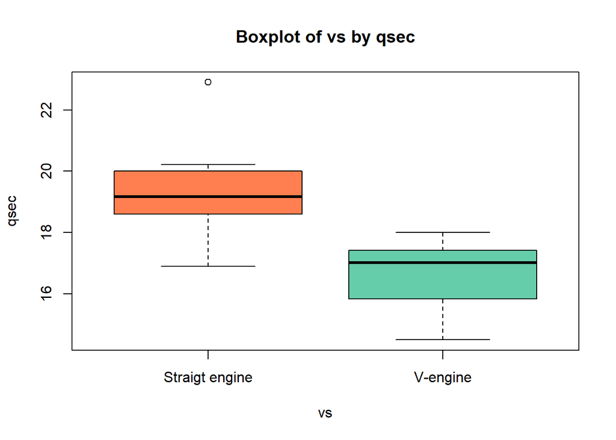

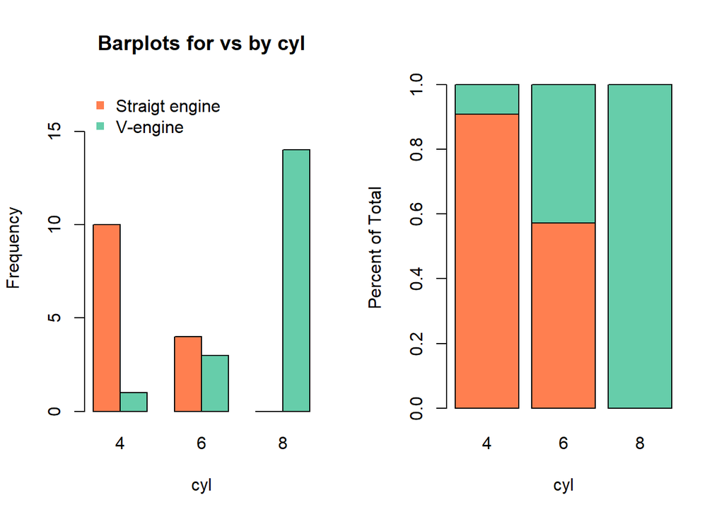

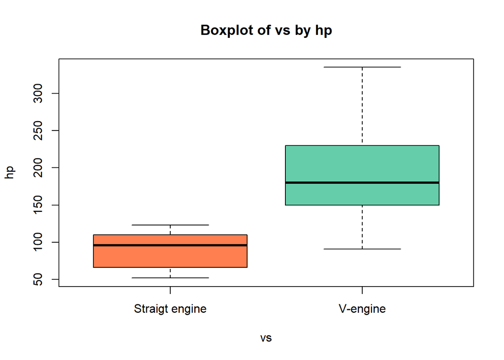

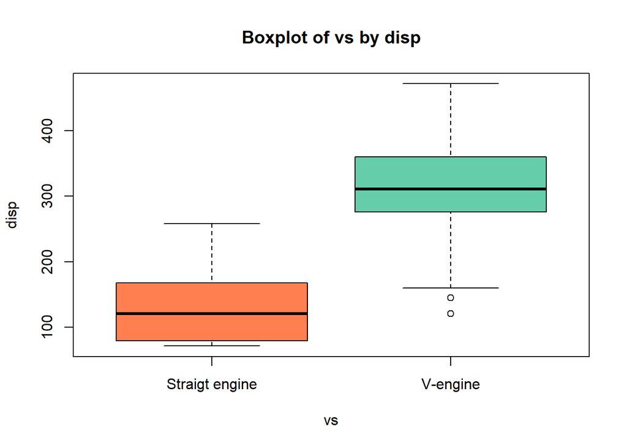

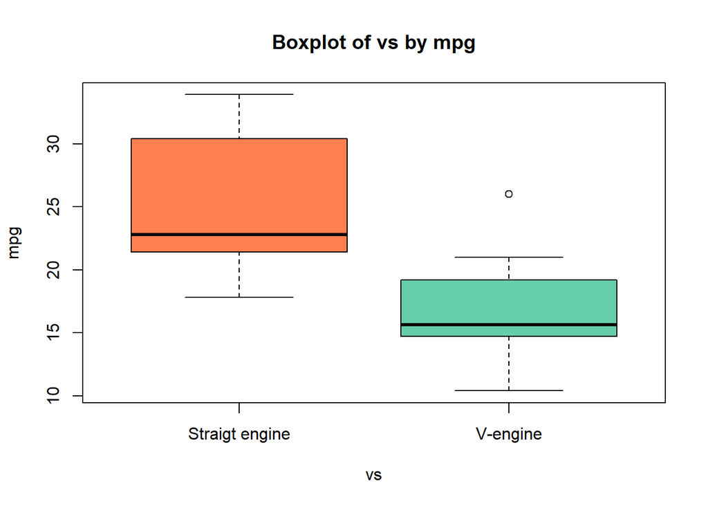

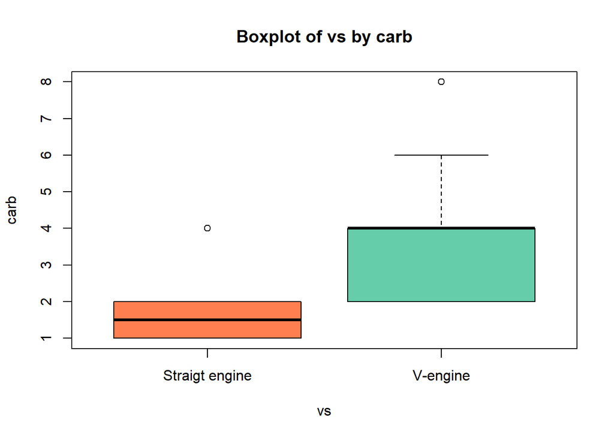

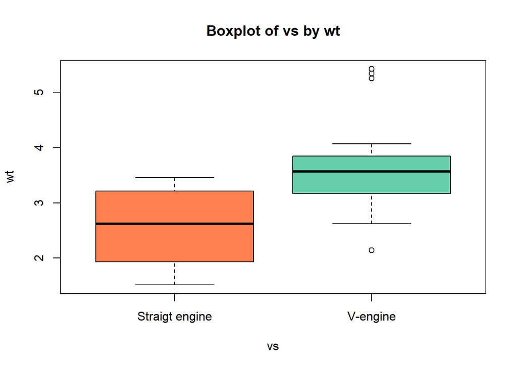

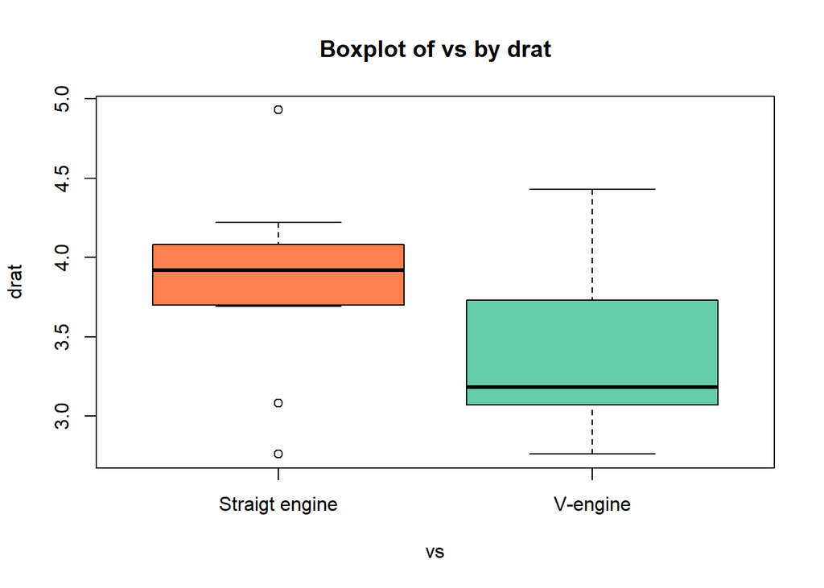

```r
lapply(IVs, f.CatDvPlots)
```